# F01 — Phenotype Atlas (HR vs LR)

Matched training work, divergent muscle growth

Author

A_HRvLR_2026

Published

July 12, 2026

## What F01 establishes

The study rests on one claim: high and low responders differ in *how their muscle responds to training*, not in how hard they trained. F01 proves the phenotype half of that before any proteomics. It walks a short chain — they did the same work, we split them by growth magnitude, and the growth itself diverges while strength does not. If the chain holds, “high vs low responder” is a biological contrast worth explaining rather than an artifact of unequal effort.

Three panels map onto that chain: **A** shows equal training work, **B** shows the split as a continuum of growth magnitude, and **C** shows where the response diverges by domain.

```r
source(here::here("04_Figures", "F01", "a_script", "setup.R"))
adv <- change_advantage_table(meta)
```

## The statistic, in plain terms

Each subject is measured before (T1) and after (T2). The question for every outcome is whether the before→after *change* differs between HR and LR. With two timepoints that is the simplest comparison there is: take each subject’s change (post − pre), then compare the two groups.

```r
# For one outcome (mCSA): each subject's change, then the HR-vs-LR comparison.
mcsa <- prepost_long(meta, "mCSA_Pre") |>
  tidyr::pivot_wider(names_from = Timepoint, values_from = value) |>
  dplyr::mutate(delta = T2 - T1)

# The two-sample t-test gives the p-value and the 95% CI of the HR-LR difference.
t.test(delta ~ Group, data = mcsa)
```

```
    Welch Two Sample t-test

data:  delta by Group
t = 2.2985, df = 10.14, p-value = 0.04403
alternative hypothesis: true difference in means between group HR and group LR is not equal to 0
95 percent confidence interval:
 0.06067727 3.68207273
sample estimates:
mean in group HR mean in group LR
        3.012625         1.141250
```

```r
# Hedges g rescales that difference into SD units, bias-corrected for small n.
effectsize::hedges_g(delta ~ Group, data = mcsa)
```

| Hedges_g | CI | CI_low | CI_high |
| --- | --- | --- | --- |
| 1.086374 | 0.95 | 0.06164152 | 2.078635 |

A `Group × Timepoint` mixed model would answer the same question, but at two timepoints it reduces to exactly this change-score comparison (Twisk et al. 2018, doi:10.1016/j.conctc.2018.03.008), so it buys nothing here. The mixed model is kept as a robustness supplement (`supp/hlm/`), where it agrees to the third decimal. Because HR and LR are balanced at baseline on every outcome, adjusting for baseline (ANCOVA) is unnecessary and, for non-randomised groups, could hide a real difference (Senn 2006, doi:10.1002/sim.2682).

We report each divergence as **Hedges g** (the HR − LR difference in the measure’s own SD units, so domains share one axis) with its 95% CI, and a two-sample p **Holm-adjusted** across the six outcomes.

## Panel A — training work (the control)

Volume load is one number per subject, so it gets a plain group comparison. A non-significant t-test does not *prove* the groups matched — at eight per group that is nearly guaranteed regardless of the truth — so we report the difference and its 95% CI and say “no detectable difference,” not “identical.”

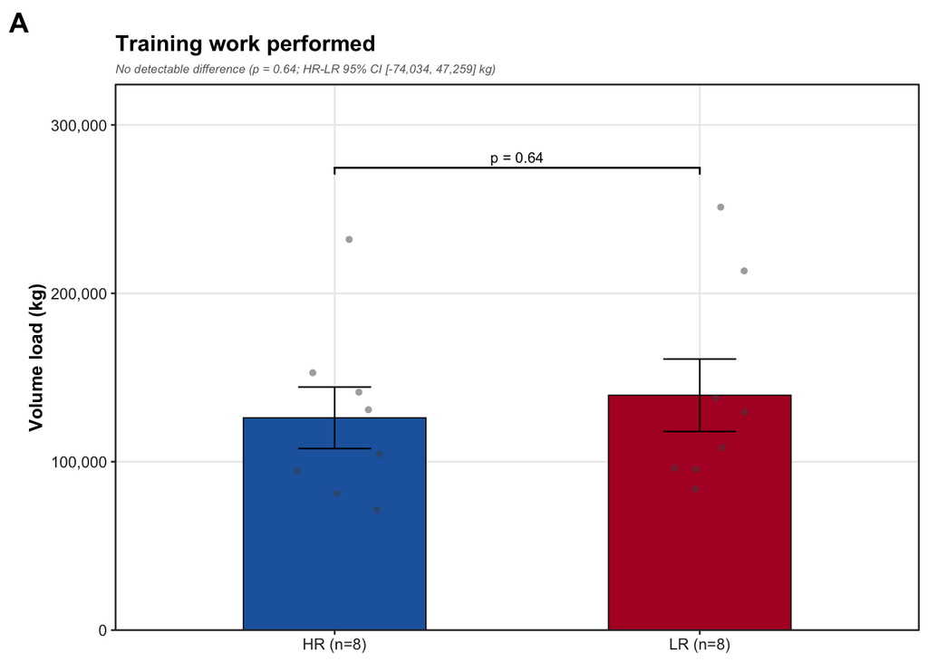

```r
build_volume(meta)$plot
```

The groups’ training work overlaps; the confidence interval spans zero and is wide, which is the honest statement at this sample size.

## Panel B — the responder split, as a continuum

The composite hypertrophy score assigns HR and LR, so a group test on it would be circular; the panel shows the split descriptively. Every subject’s composite score is ranked, the dashed line is the HR/LR boundary, and the grey band is a distribution-based 0.2 × SD zone (a measurement-error band would need test-retest data we lack). Responders run smoothly from one tail to the other and the cut lands in an empty gap, so no subject sits ambiguously at the boundary. The gap is partly built in — sorting by the defining score puts a break at the cut — so read it as a clean split by magnitude, not proof of two natural kinds.

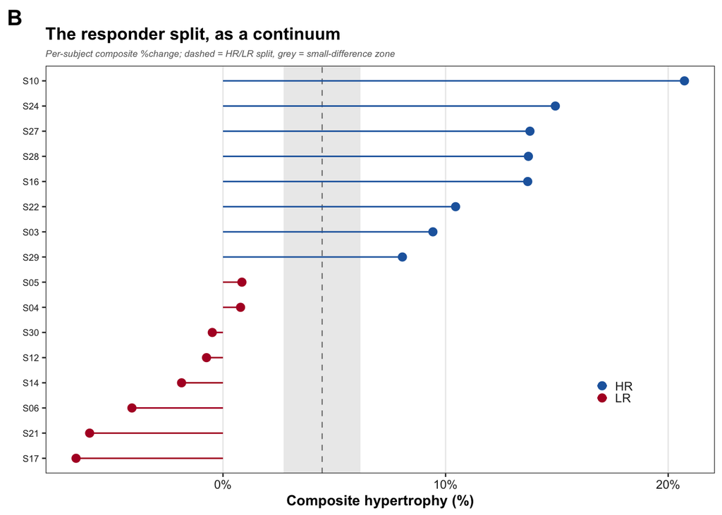

```r
build_continuum(meta)$plot
```

## Panel C — phenotype change by domain

For each outcome, the HR − LR change in SD units (Hedges g) with its 95% CI and the Holm-adjusted p. Read it with the split’s origin in mind: the groups were **defined** by muscle and fibre growth, so those rows show the magnitude of the defining split, not an independent finding. Strength is the independent test.

```r
knitr::kable(adv, digits = 3)
```

| measure | domain | estimate | ci_lo | ci_hi | p | p_holm |
| --- | --- | --- | --- | --- | --- | --- |
| mCSA | muscle | 1.086 | 0.062 | 2.079 | 0.044 | 0.132 |
| fCSA Mixed | fibre | 1.822 | 0.658 | 2.943 | 0.002 | 0.007 |
| fCSA Type I | fibre | 2.036 | 0.824 | 3.204 | 0.001 | 0.006 |
| fCSA Type II | fibre | 1.963 | 0.768 | 3.115 | 0.001 | 0.006 |
| 1RM Leg Press | strength | 0.127 | -0.803 | 1.052 | 0.793 | 1.000 |
| 1RM Extension | strength | 0.237 | -0.726 | 1.191 | 0.632 | 1.000 |

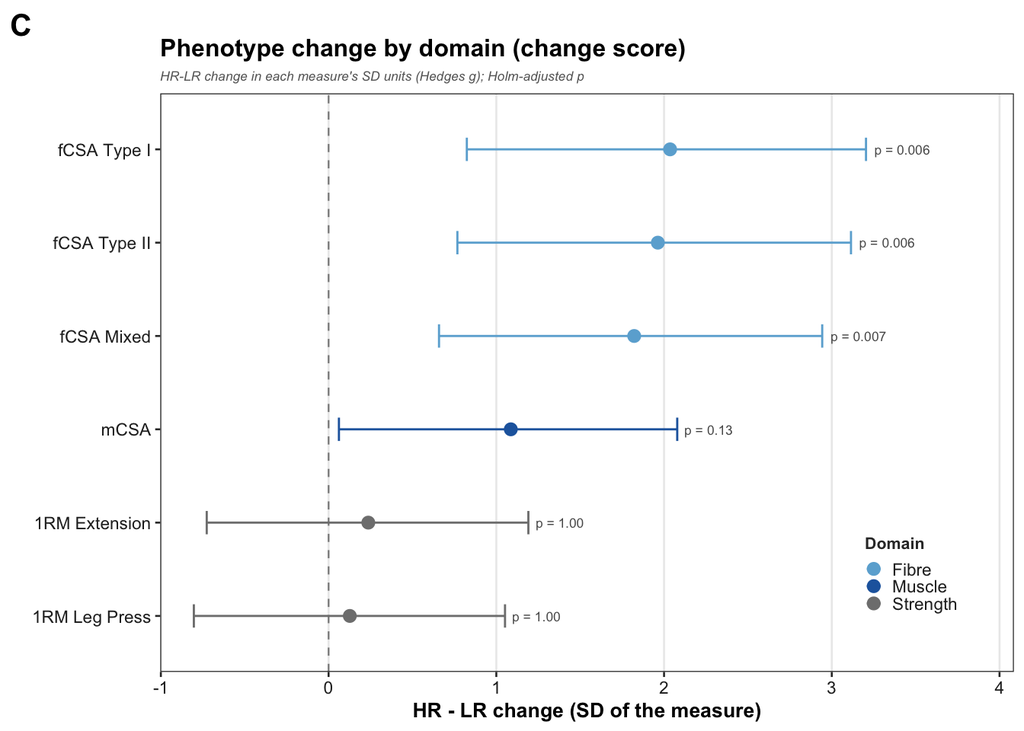

```r
build_forest(meta)$plot
```

The divergence is carried by fibre-level growth: fibre CSA (type I, type II, mixed) clears zero with Holm p ≈ 0.006. Whole-muscle mCSA is suggestive (g ≈ 1.1, CI just clears zero) but not significant after Holm. Both strength measures are flat (g ≈ 0, Holm p = 1.0). So HR and LR trained to the same strength yet grew apart at the fibre level — the strength null is the independent result, the fibre divergence is the magnitude of the phenotype that defines the groups.

## Supplements

The **phenotype** supplement (`supp/pheno/`) is the raw change score by group for every outcome, faceted with the Holm-adjusted p per strip: manually traced fibre CSA rises in HR and falls in LR while strength gains match. The MyoVision fibre columns are excluded upstream — their values (200–560) sit 10–30× below plausible fibre CSA and correlate negatively with manual tracing, the signature of a fibre-count metric mislabelled as area (MyoVision reports CSA in thousands of µm²; Wen et al. 2018, doi:10.1152/japplphysiol.00762.2017).

The **mixed-model** supplement (`supp/hlm/`) fits `value ~ Group * Timepoint + (1 | subject)` per outcome and shows it reproduces the change-score result, with a `performance::check_model` assumption suite and the full coefficient, fit, contrast, and leave-one-subject tables in `F01_lmm_report.qmd`.

## c_data — the source workbook

`c_data/F01_source_data.xlsx` holds four sheets. `summary_by_measure` is one row per measure and group: the change-score mean, the Hedges g advantage with its CI, the raw and Holm-adjusted p, and the mixed-model ICC. `controls_and_axis` holds the volume and composite group means and the per-subject responder axis. `hlm_fit_summary` gives each mixed model’s R²/ICC/fit. `metadata` records the design and analysis.

## Key terms

**Change score** — each subject’s post − pre. Comparing the change between groups is the divergence test; at two timepoints it equals the mixed-model interaction.

**Hedges g** — the HR − LR difference in the measure’s own SD units (a bias-corrected Cohen’s d). Above zero, HR gains more; one axis fits every domain.

**Holm adjustment** — a step-down control of the false-positive rate across the six outcomes. More conservative than showing raw p, less than assuming independence.

**Circularity** — the groups are defined by the composite growth score, so panels B and the muscle/fibre rows of C describe the split rather than test it independently. Strength is the one independent contrast.

**Equivalence vs a null** — a non-significant t-test says “no detectable difference,” not “the same.” Proving sameness needs an equivalence test and a pre-set threshold, which at n = 8/group would be inconclusive, so we report the interval and stop there.

## Recap

- Matched work, divergent growth: overlapping volume and strength, HR-favoured fibre growth.
- One simple engine (the change-score comparison) carries every panel; the mixed model is a supplement that agrees.
- The split is shown as a continuum of magnitude, never tested against itself.
- A mislabelled MyoVision column was caught and excluded rather than read as hypertrophy.